# Unit 2 : Getting started with R and ggplot

# 1 Introduction

Welcome back to POLI LIT! By now, you’ve had a chance to explore what data is and how it can help us understand the world. In **Unit 2**, we build on that foundation by focusing on two essential skills: **understanding how to communicate with data visually** and **learning to use R** — a powerful, free programming language for data analysis.

This unit is structured around four interconnected areas:

1. **Reading and interpreting basic visualizations**  
   We’ll start by looking at real examples — a line plot tracking GDP per capita and a bar chart of IGO memberships — so you can practice connecting code to visual output before writing any code yourself.
2. **Getting started with R and Posit Cloud**  
   You’ll set up your coding environment using Posit Cloud (a free, browser-based platform), learn your way around the RStudio interface, and load the `POLI_LIT` dataset that we use throughout the course. No installation required!
3. **R fundamentals**  
   We’ll walk through the core building blocks of R: running code, working with variables and objects, understanding different data types, and using key functions like `filter()`, the pipe operator `%>%`, and the `$` operator to access columns in a dataset.
4. **Building data visualizations with `ggplot2`**  
   You’ll learn how to construct plots layer by layer — starting from a minimal line plot, then adding points, labels, and themes — using India’s Electoral Democracy Index as a worked example. By the end, you’ll customize your own plot for a country of your choice.

By the end of this unit, you should feel confident setting up R, understanding what your code is doing, and creating clear, well-labeled visualizations from real political science data. The goal isn’t flashy graphics — it’s charts that tell a clear, honest story.

**What to Submit for Full Credit**

To receive full credit for Unit 2, make sure you submit the following:

- *Final Practice (Plot + Description)*
- *Unit 2 Feedback Form*

An optional practice plot activity is also available — this is **not required**, but completing it will genuinely reinforce your skills before the final task.

> 💡 *We strongly encourage you to follow each step in the unit carefully and practice the code as you go. Working through the examples hands-on will make the final tasks much more manageable.*

## 1.1 Getting Started: Can You Read These Plots?

Before we dive deeper, here are **two types of plots** you should already be somewhat familiar with:

- A line plot (often used to show change over time)
- A bar plot (used to compare categories)

Take a look at the code below for each plot. Don’t worry if it looks a little confusing — just do your best to follow along and think about what each part is doing.

> 🔍 Can you guess what each line of code is doing? Try to connect the code to the visual output.

### 1.1.1 Line plot

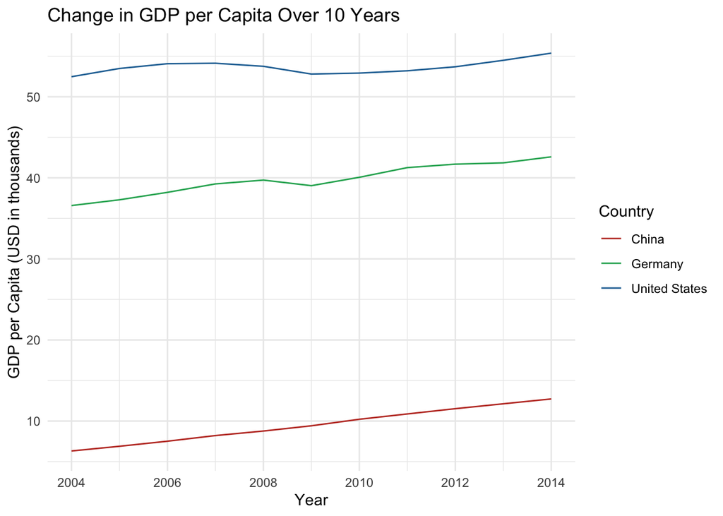

```r
p1 <- POLI_LIT %>%
  filter(year >= 2004) %>%
  filter(country_name %in% c("United States", "China", "Germany"))

ggplot(p1, aes(x = year, y = e_gdppc, colour = country_name)) +
  geom_line() +
  scale_color_manual(values = c("United States" = "#2471A3",
                                "China" = "#C0392B",
                                "Germany" = "#27AE60")) +
  labs(
    x = "Year",
    y = "GDP per Capita (USD in thousands)",
    title = "Change in GDP per Capita Over 10 Years",
    colour = "Country"
  ) +
  theme_minimal()
```

**How to read this plot**:

- The x-axis shows time in years.
- The y-axis shows each country’s GDP per person (a common measure of national income).
- Each colored line represents one country.

This kind of line plot helps us track economic changes over time and compare how different countries grow or slow down.

### 1.1.2 Bar plot

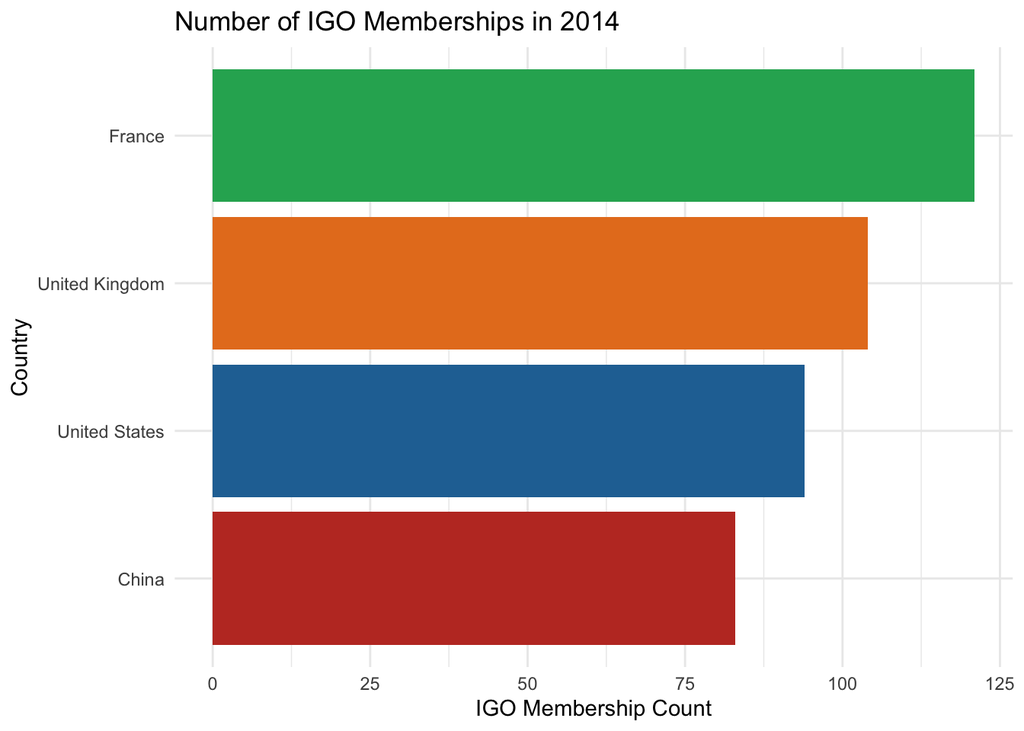

```r
p2 <- POLI_LIT %>%
  filter(year == 2014) %>%
  filter(country_name %in% c("United States", "China", "France","United Kingdom"))

ggplot(p2, aes(x = reorder(country_name, IGO_count), y = IGO_count, fill = country_name)) +
  geom_col(show.legend = FALSE) +
  scale_fill_manual(values = c("United States" = "#2471A3",
                               "China" = "#C0392B",
                               "France" = "#27AE60",
                               "United Kingdom" = "#E67E22")) +
  coord_flip() +
  labs(
    title = "Number of IGO Memberships in 2014",
    x = "Country",
    y = "IGO Membership Count"
  ) +
    theme_minimal()
```

**How to read this plot**:

Even a simple bar plot like this invites us to think about how countries engage with the world—highlighting important themes like global participation and cooperation through IGOs.

## 1.2 What is R and RStudio?

Now that you’ve seen some example plots, take a closer look at the **code** that created them.  
Notice how each part of the code tells R exactly **what we want to do**:

- `filter()` helps us *select* specific years or countries from a dataset
- `labs()` is used to *customize labels* like the plot title or axis names
- `geom_col()` or `geom_line()` decides *what kind of plot* to draw

Each function serves a purpose — just like giving precise instructions to a robot.

If this is your first time writing code, don’t stress. Just follow the steps one by one — we’ll guide you the whole way.Our main goal for R coding in this unit is for you to:

- Set up your R environment using Posit Cloud (a browser-based tool — no installation needed)
- Learn the basic structure of R code
- Make your first visualization using R and the `ggplot2` package

> 💡Coding in R is not like talking to an AI chatbot. R follows your instructions **exactly as written** — so things like spelling, punctuation, and parentheses really matter. A small typo can cause your code not to run!

### 1.2.1 What is R

**R** is a computer language made for **data analysis and visualization**.  
Scientists, journalists, and governments use it every day to understand information and share results clearly.

You can think of R as a **toolbox** filled with functions for:

- Reading and organizing data
- Doing calculations and statistics
- Making graphs and maps

R is also **open-source**, which means it’s free and anyone can improve it.  
Because of that, thousands of researchers around the world—especially in *political science* —build and share new tools for others to use.

Learn more about other trending languages here - [“Top 12 Programming Languages for Data Science Languages in 2025.”](https://www.datacamp.com/blog/top-programming-languages-for-data-scientists-in-2022).

### 1.2.2 What is RStudio / Posit Cloud?

When you use R by itself, you are typing commands into a plain window—just a blinking cursor waiting for instructions. That works fine for experts, but it can feel uncomfortable if you are new to coding.

That is why we use **RStudio**. RStudio is a program that makes R much easier to use. It gives you a clear, organized workspace so you can see your code, data, and results all in one place (You might see people call RStudio an *IDE*, which stands for *Integrated Development Environment*).

Don’t worry if that sounds technical. It just means that RStudio brings everything you need together in one space:

- You can **write** code.
- You can **run** code and see what happens.
- You can **look at** your data and graphs.
- You can **get help** when something does not work.

In short, an IDE is a workspace that combines all your tools in one window. Instead of installing RStudio on your own computer, we will use **Posit Cloud**, which is the online platform to run RStudio.It works right in your web browser—just like Google Docs—so you do not need to install anything.

[figure not shown]

> **A way to think about this dynamic:**  
> - *R* is the *engine* that makes the car move.  
> - *RStudio* (or Posit Cloud) is the *dashboard* that helps you drive the car safely and easily. The dashboard shows your speed, directions, and fuel level—so you can focus on where you are going, not how the engine works.

## 1.3 Using Posit Cloud

### 1.3.1 How to Create and Open a Project on Posit Cloud

To start working with R and coding, we will use **Posit Cloud**, a platform/website that lets you use RStudio in your web browser.

If you already have *R* and *RStudio* installed on your computer, you can follow along with this unit using your desktop version. But for this module, we recommend **Posit Cloud** for everyone who are trying R the first time. You don’t have to install anything— everything runs online and is saved automatically.

- **Step 1: Register for a Free Account**

  Visit https://posit.cloud and click **Sign Up** to create a free account.You can sign in using Google or GitHub if you prefer.

  Once you’ve registered, Posit Cloud will open your personal workspace—just like logging into Google Drive for the first time.
- **Step 2: Create or Open a Project**

  A *project* is like a folder that keeps everything you do in one place: your code, datasets, and any graphs or reports you make. You can think of a project as your personal research folder inside RStudio. Keeping your work in projects helps you stay organized and avoid mixing files from different assignments.

  **Follow the steps in this webpage** to create your first project (read up to the *“Start Shiny App Steps”* section.):  
  [How to get started with Posit Cloud (Posit Docs)](https://docs.posit.co/cloud/get_started/)

### 1.3.2 Understanding the Interface

When your project opens, you’ll see the **RStudio / Posit Cloud workspace**.  
It looks like this:

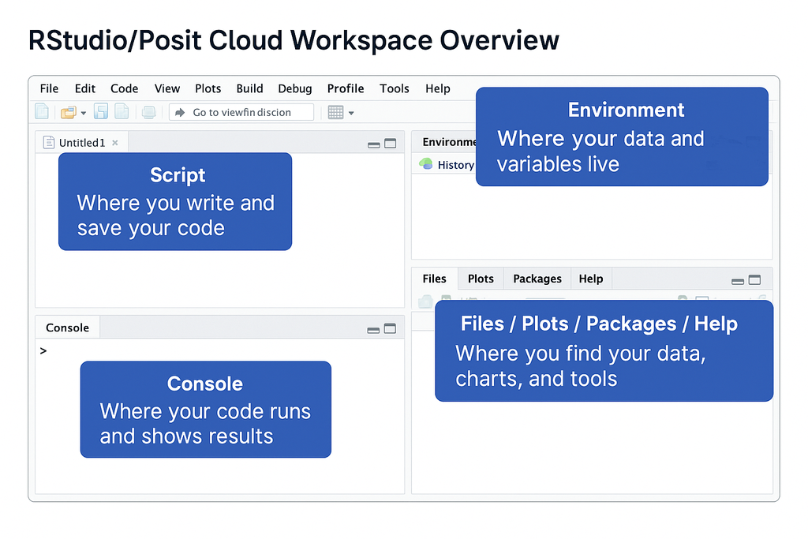

When you open **RStudio** the first time, you should notice the screen is divided into **four main panels**. Each one plays a different role — and together, they make writing and running R code much easier.

- **Script Editor** (Top-Left)  
  This is your *notebook*.  
  Write your code here and save it for later.  
  You can run a line (or section) by clicking the *Run* button or pressing `Cmd + Enter` (Mac) / `Ctrl + Enter` (Windows).
- **Console** (Bottom-Left)  
  This is R’s *work area*.  
  When you run code, the Console shows what’s happening — results, errors, or messages.  
  Think of it as R’s “chat box”: it shows replies to your commands.
- **Environment & History** (Top-Right)  
  – *Environment:* Keeps track of what you’ve created — datasets, variables, etc.  
  – *History:* A record of every command you’ve run.
- **Files / Plots / Packages / Help** (Bottom-Right)  
  – *Files:* Shows what’s saved in your R project folder.  
  – *Plots:* Displays the graphs you create.  
  – *Packages:* Lists extra tools you’ve installed.  
  – *Help:* Use this when you forget how a function works!

> 🔍 As you work through this unit, don’t be afraid to click around each panel in RStudio to see what it does. You don’t need to memorize everything — just knowing where things are will help a lot. Also, if you close your browser, Posit Cloud automatically saves your work.

### 1.3.3 Setting the Working Directory

Before we start analyzing data, you need to tell R where your files live. This location is called your **working directory** — it’s the folder R looks in when you open or save things.

You should already have your **Posit Cloud account** set up now. For this step, please download the **POLI_LIT dataset** and the **codebook PDF** from Blackboard Unit 2 folder.

Save both files on your computer:

- `POLI_LIT_v1.csv`
- `POLI_LIT_v1_codebook.pdf`

> 💡On Posit Cloud, you can upload files directly to your project. If you’re using RStudio on your computer instead, make sure your data file and your `.Rmd` file are saved in the **same folder** so R can find them.

#### 1.3.3.1 Why the Working Directory Matters

Think of your working directory as R’s *home base or inventory.* If R doesn’t know where to look, it can’t find your data or save your charts.

- When you read a file (data), R looks in your working directory and load it into R Studio.
- When you save a graph, R also saves it there by default.

You can **check** or **set** your working directory using these commands:

```r
getwd()   # shows your current working directory
setwd("/cloud/project")  # sets it to your Posit Cloud project folder
```

> **On Posit Cloud:** Your project folder is automatically your working directory (`/cloud/project`).  
> **On RStudio Desktop:** You need to set your working directory manually through `setwd("your folder path")` code.  
> In `.rmd` and `.qmd` file, using r code need code chunk, check this link for more: [here](https://rmarkdown.rstudio.com/lesson-3.html)

### 1.3.4 Uploading Datasets

Now that R knows where to look, let’s bring your dataset into R!

Follow these steps carefully:

1. In Posit Cloud, go to the **Files** tab (bottom-right panel).
2. Click the **Upload** button.
3. Select your dataset file — `POLI_LIT_v1.csv`.
4. Once it uploads, you should see it appear in the Files panel.

Now, we’ll read it into R using this code:

```r
POLI_LIT <- read.csv("POLI_LIT_v1.csv")
head(POLI_LIT)
```

This code tells R to:

- **Read** the CSV file named `POLI_LIT_v1.csv`, and
- **Show** the first six rows of data using the `head()` function.

If it worked, you’ll see a small preview of your dataset that looks like this:

[figure not shown]

> 💡 If R says *“cannot open file”* or *“no such file”*, check that your file name matches exactly (including capital letters) and that it’s saved in your working directory.  
> [Official guide of input data into posit cloud](https://docs.posit.co/cloud/guide/data/)  
> [Video to input data and export result file](https://youtu.be/FSiDrlOAjgo?si=4LGmjU2apnAcfesZ)  
> If you are using *RStudio installed on device*, you can follow this official guide:  
> [Importing data into RStudio (Posit Support)](https://docs.posit.co/ide/user/ide/guide/data/data-local.html)

Next, you can click on the “POLI_LIT” in your environment panel to open the viewing window for data like this:

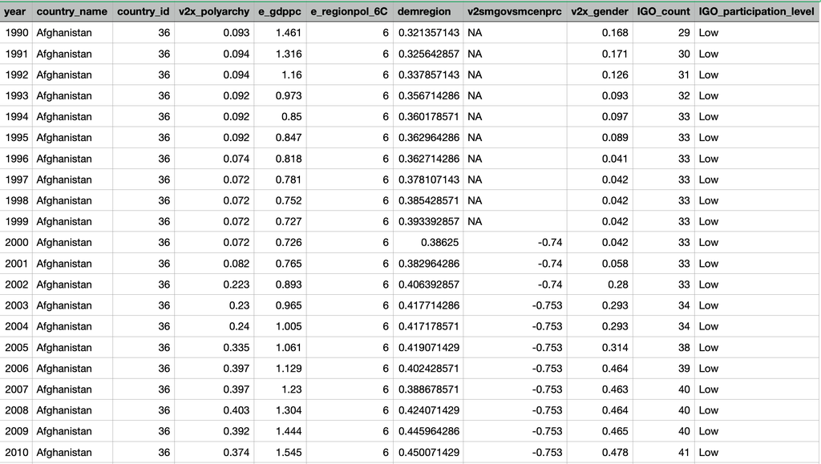

Coming up next, we’ll make our **first simple plot** using the POLI_LIT dataset.  
You’ll see how just a few lines of code can turn raw data into a clear and meaningful visualization!

## 1.4 Knowledge check

### 1.4.1 Check List

Before continue to the next section, make sure you:

1. Register Posit Cloud account and open your first project.
2. Run `getwd()` to check your working directory.
3. Upload `POLI_LIT_v1.csv` and read it with `read.csv()`.
4. Type `head(POLI_LIT)` to view the first few rows.

### 1.4.2 Practice Quiz

**1. Which part of the RStudio interface shows your R commands and error messages?**

a) Environment

b) Files pane

c) Console

**2. The Script Editor (top-left panel) is used for:**

a) Writing and saving code you want to reuse

b) Showing images only

c) Installing packages only

**3. What does the command `getwd()` do?**

a) Uploads your dataset

b) Shows your current working directory

c) Runs a plot

**4. R and RStudio are the same thing.**

a) True

b) False

**5. A small typing error (like a missing parenthesis) can prevent R code from running.**

a) True

b) False

# 2 Exploring R: Basic

In this section, we will explore what R can *do* and *learn the basic logic* behind how it works.  
You have already seen R Studio’s workspace and learned how to create a project. R might look complicated at first, but at its core, it is simply a tool that:

- reads and stores data
- performs calculations
- helps us analyze and visualize data

Think of R as a **powerful calculator** that can also work with entire datasets.

We’ll start with small steps so you can get comfortable running code and understanding what R is doing.

## 2.1 Writing R Code

Besides working with existing datasets, R can also do many other tasks—like solving math problems or making quick calculations. This is a good way to practice how R ‘thinks’ and ‘operate.’

You can write and run code in two places:

- **Console:** for quick, one-time commands.
- **Script Editor:** for code you want to save and reuse later.

If you’re not sure where these are, go back to the previous section *“Using Posit Cloud”* and look at the workspace diagram.

> 💡 R reads and runs commands **line by line**.  
> You can run a line of code by selecting the line(s) and pressing **Run** (the green button at the top of your Script pane) or using **Ctrl + Enter** (Windows) / **Cmd + Enter** (Mac).

### 2.1.1 Try It Yourself: Basic Math in R

R can do simple math just like a calculator. Copy and paste the code below into your Posit Cloud project. You’ll see results in the **Console**, right below your commands.

```r
# --- 1. Basic Math Operations ---
# R can perform mathematical calculations directly.
# Try Copy Paste these and run in your project!

5 + 3   # Addition
10 - 4  # Subtraction
6 * 7   # Multiplication
20 / 5  # Division
2^3     # Exponentiation
sqrt(25) # Square root

# Other useful functions:
log(10)  # Natural logarithm
exp(2)   # Exponential function
round(3.14159, 2)  # Rounds to 2 decimal places
```

### 2.1.2 What You’ll See

When you run these commands, R prints each answer immediately in the Console.

It looks like this:

```r
6 * 7    # Multiplication
```

```
## [1] 42
```

```r
sqrt(25) # Square root
```

```
## [1] 5
```

```r
log(10)  # Natural logarithm
```

```
## [1] 2.302585
```

```r
exp(2)   # Exponential function
```

```
## [1] 7.389056
```

> 💡 **Important:**  
> Text that starts with the `#` symbol is a **comment**. Use comments to make notes for yourself—what the code does, or why you wrote it.  
> For example: `5 + 3 # Adds 5 and 3 together`. R ignores anything that comes after `#` on a line. So it will print ‘8’ as result and ignore ‘Adds 5 and 3 together.’

## 2.2 What is a Variable or Object?

Now that you can run simple commands, the next step is to learn how R stores information using **objects** (also called **variables**).

You can think of an object as a labeled box where R keeps something you want to use later-

A *number*, *text*, a *list of values*, or even a whole *dataset*.

### 2.2.1 Creating a Variable (or Object)

R stores information in objects that you can name yourself. You create an object using the **assignment arrow** `<-`, which means: take the value on the right and store it in the name on the left.

```r
# Example: create an object
x <- 5  #store the value 5 in the object call 'x'
y <- 10 #store the value 10 in 'y'

# Use objects in calculations
x + y # add them
```

Here, `x` and `y` store numeric values (5 and 10), and R keeps track of them until you remove them or end your session.

> 💡 You’ll see all your objects appear in the **Environment** pane (top-right).

### 2.2.2 What Can R Store in Objects?

R objects can contain many kinds of information, including a single number, a text string (e.g., “India”), a **vector** (a list of values), or a **data frame** (a full dataset with rows and columns).

When you load a dataset using `read.csv` function like this:

```r
data <- read.csv("POLI_LIT_v1.csv")
```

The `<-` assigns the dataset to the object named `data`.

You can name it to anything you like, such as `poli_lit`, `df`, or `mydata`. Like this:

```r
POLI_LIT <- read.csv("POLI_LIT_v1.csv")
```

Now the entire dataset (POLI_LIT_v1.csv) is stored in an object named `POLI_LIT`.

### 2.2.3 What About the `$` Symbol?

When you import a dataset, it becomes a **data frame**, which works like a table. Each column has a name, and the `$` operator lets you access one column at a time.

Example:

```r
data$year
# This means - take the column named 'year' from the dataset (object) called 'data'

poli_data$v2x_polyarchy
# Take the column named 'v2x_polyarchy' from the dataset (object) called 'poli_data'
```

You can use `$` to look at values, calculate statistics, use the variable in a plot, or filter/subset your data. You will use $ frequently when summarizing variables or making plots!

Example:

```r
mean(data$v2x_polyarchy)
# Calculate the mean of variable (column) 'v2x_polyarchy' from the dataframe (object) called 'data'
```

## 2.3 Understanding Data Types and Exploring Data

Now that we’ve covered the theoretical foundations in Unit 1, it’s time to put those concepts into practice. In this unit, we will explore the dataset you loaded earlier (`POLI_LIT_v1.csv`), which is stored as a dataframe called `POLI_LIT`. Each column (or *variable*) in this dataset can hold a different **data type** — some are numbers, others are text, and some may be logical (TRUE/FALSE). Recognising which type each variable belongs to helps you decide which functions and visualisations are appropriate.

### 2.3.1 From Theory to Practice: How Data Types Map to R

In Unit 1, you learned to classify variables by their **measurement level** — nominal, ordinal, interval, or ratio. The table below maps each level back to real variables in `POLI_LIT`, so that when you see a column in R you already know which questions you can and can’t ask of it (e.g., can you take an average? does “zero” mean anything?):

| Level of Measurement | Definition | Example in `POLI_LIT` |
| --- | --- | --- |
| **Nominal** | Categories with no meaningful order | `e_regionpol_6C` (region codes), `country_id` |
| **Ordinal** | Ranked categories with unequal spacing | `IGO_participation_level` (Low/Medium/High) |
| **Interval** | Equal spacing, but no true zero | `v2x_polyarchy`, `v2x_gender` |
| **Ratio** | Equal spacing with a meaningful zero | `e_gdppc` (GDP per capita), `IGO_count` |

When R actually reads your data, it stores each variable as one of its own **technical data types**:

| R Data Type | What it stores | Typical measurement level |
| --- | --- | --- |
| `character` | Text strings | Usually nominal |
| `integer` | Whole numbers | Often nominal or ordinal |
| `numeric` (double) | Decimal numbers | Interval or ratio |
| `logical` | TRUE / FALSE values | Nominal (binary) |
| `factor` | Labelled categories | Nominal or ordinal |

> 💡 **Key insight:** The same variable can look different in theory versus in R. For example, `e_regionpol_6C` is *nominally* scaled in theory, but R may store it as `integer` because region codes happen to be numbers. Always check the codebook alongside the R output — a number in R does not automatically mean a quantity worth doing arithmetic on.

### 2.3.2 Loading the Dataset

Before we can explore the data, we need to make sure R knows where to find it. The following commands help R locate your files and load the dataset:

```r
getwd()                              # Shows your current working directory
setwd("/cloud/project")              # Sets it to your Posit Cloud project folder
POLI_LIT <- read.csv("POLI_LIT_v1.csv")  # Loads the CSV file and names it 'POLI_LIT'
```

> 💡 If the file name is not typed exactly as it appears on disk, R will not find it. Pay attention to capitalisation, hyphens (`-`), and underscores (`_`).

### 2.3.3 Preview the Data

Start by looking at what the dataset actually contains. The `head()` command shows the first six rows of your dataframe, giving you a quick preview of how the data is structured:

```r
head(POLI_LIT)   # Shows the first 6 rows of the dataset
```

```
##   X year country_name country_id v2x_polyarchy e_gdppc e_regionpol_6C demregion
## 1 1 1990       Mexico          3         0.396  11.389              2   0.55928
## 2 2 1991       Mexico          3         0.418  11.635              2   0.57996
## 3 3 1992       Mexico          3         0.441  11.883              2   0.58480
## 4 4 1993       Mexico          3         0.451  11.983              2   0.59928
## 5 5 1994       Mexico          3         0.472  12.043              2   0.60964
## 6 6 1995       Mexico          3         0.489  11.742              2   0.61876
##   v2smgovsmcenprc v2x_gender IGO_count IGO_participation_level
## 1              NA      0.534        74                    High
## 2              NA      0.505        73                    High
## 3              NA      0.505        72                    High
## 4              NA      0.516        74                    High
## 5              NA      0.631        82                    High
## 6              NA      0.636        83                    High
```

### 2.3.4 Check the Structure and Data Types

Next, use `str()` to see the *structure* of the dataset — this is where you can directly observe R’s technical data types for each column:

```r
str(POLI_LIT)   # Shows the structure of the dataset
```

```
## 'data.frame':    3314 obs. of  12 variables:
##  $ X                      : int  1 2 3 4 5 6 7 8 9 10 ...
##  $ year                   : int  1990 1991 1992 1993 1994 1995 1996 1997 1998 1999 ...
##  $ country_name           : chr  "Mexico" "Mexico" "Mexico" "Mexico" ...
##  $ country_id             : int  3 3 3 3 3 3 3 3 3 3 ...
##  $ v2x_polyarchy          : num  0.396 0.418 0.441 0.451 0.472 0.489 0.511 0.56 0.599 0.605 ...
##  $ e_gdppc                : num  11.4 11.6 11.9 12 12 ...
##  $ e_regionpol_6C         : int  2 2 2 2 2 2 2 2 2 2 ...
##  $ demregion              : num  0.559 0.58 0.585 0.599 0.61 ...
##  $ v2smgovsmcenprc        : num  NA NA NA NA NA NA NA NA NA NA ...
##  $ v2x_gender             : num  0.534 0.505 0.505 0.516 0.631 0.636 0.636 0.636 0.636 0.636 ...
##  $ IGO_count              : int  74 73 72 74 82 83 83 83 84 86 ...
##  $ IGO_participation_level: chr  "High" "High" "High" "High" ...
```

The `str()` output will tell you:

- The total number of rows (observations) and columns (variables)
- A short preview of values in each column
- The **R data type** of each column, such as:
  - `num` / `numeric`: decimal numbers (e.g., `v2x_polyarchy`, `e_gdppc`)
  - `int` / `integer`: whole numbers (e.g., `year`)
  - `chr` / `character`: text strings (e.g., `country_name`)

This is the moment to cross-reference with your codebook. Ask yourself: does the R type match what you would theoretically expect? For instance, if `e_regionpol_6C` appears as `int`, remember that it is still a *nominal* variable — the numbers are codes, not quantities.

### 2.3.5 Explore the Dataset with Summary Functions

R provides several built-in functions that quickly describe an entire dataset:

```r
summary(POLI_LIT)     # Summarises all variables (min, max, mean, NAs, etc.)
nrow(POLI_LIT)        # Number of rows (observations)
ncol(POLI_LIT)        # Number of columns (variables)
colnames(POLI_LIT)    # Lists all column names
```

> 💡 These are essential tools for getting to know an unfamiliar dataset. Try running them one by one and see what each returns.

### 2.3.6 Analyse a Single Variable

You can also apply summary functions to one column at a time using the `$` operator. For example, to calculate the **mean** of GDP per capita (`e_gdppc`):

```r
mean(POLI_LIT$e_gdppc, na.rm = TRUE)
```

Here: - `POLI_LIT$e_gdppc` tells R to look at the column `e_gdppc` inside the dataframe `POLI_LIT`. - `na.rm = TRUE` removes any missing values before calculating, so they don’t cause an error.

You can get a broader overview of the same column with:

```r
summary(POLI_LIT$e_gdppc)
```

```
##    Min. 1st Qu.  Median    Mean 3rd Qu.    Max.
##   0.286   2.811   7.859  13.951  20.623 100.865
```

> 🔍 Replace `e_gdppc` with other column names, such as `year`, `country_name`, or `IGO_count`. What kind of information does `summary()` return for a `character` column compared to a `numeric` one? How does this relate to the measurement levels you learned in Unit 1?

## 2.4 Practice (Optional)

1. Create and print an object: For example, run `x <- 5` and then type x to display its value.
2. Load the dataset and view basic summaries: Use `summary(POLI_LIT)` to see an overview of all variables.
3. Explore the structure of the dataset: Run the following and write a short comment on what each one shows:
   - `head(POLI_LIT)`
   - `str(POLI_LIT)`
   - `nrow(POLI_LIT)`
   - `ncol(POLI_LIT)`
4. Analyze a single variable: `mean(POLI_LIT$e_gdppc, na.rm = TRUE)` Explain what this number represents in the context of your dataset.

After completing these steps, try write few sentences describing:

- what type of dataset you are working with, and
- what that variable measures and the descriptive statistics (mean, max/min value etc).

## 2.5 Knowledge check

### 2.5.1 Check List

Before continuing to the next section, make sure you can:

1. Run basic R commands in the Console and Script Editor.
2. Create objects using `<-` and understand how R stores them.
3. Load the dataset using `read.csv()` and see it in your Environment.
4. Use the `$` operator to access a single variable.
5. Run basic data exploration functions:
   - `head()`
   - `str()`
   - `summary()`
   - `nrow() and ncol()`
6. Explain (in simple words) what a data frame is and what a variable is.

### 2.5.2 Pratice Quiz

**1. What does `na.rm = TRUE` do in a function like `mean()`?**

a) Ignores missing values

b) Converts all values to NA

c) Rounds values

**2. Which function shows the first few rows of a dataset?**

a) summary()

b) head()

c) names()

**3. What does this code do? `x <- 10`**

a) Prints the number 10

b) Creates an object named x that stores the value 10

c) Multiplies x by 10

**4. R ignores any text after a `#` symbol on a line.**

a) True

b) False

**5. `POLI_LIT$year` means - accessing one specific column named "year" from that dataset "POLI_LIT". POLI_LIT.”**

a) True

b) False

# 3 Making Your First Plot

Now that you’ve gone through the basics of using R, it’s time for the exciting part — making your **first plot**!

In this section, we’ll guide you step-by-step through how to use `ggplot2`, a powerful R package for creating visualizations.

> 🔍 There is an **optional practice activity** at the end, and we strongly encourage you to complete it. It’s great preparation for the final practice (required), where you’ll be asked to make your own plot and submit it through Blackboard.

**Recap: How to Run Code**

To **run** a line of R code:

- Click inside the line (or select line(s)) and press the **Run** button at the top of your Script pane.
- Or use shortcuts:
- **Windows:** `Ctrl + Enter`
- **Mac:** `Cmd + Enter`

[figure not shown]

Your results will appear in the **Console** (bottom-left).

> 🔍 The [Posit RStudio User Guide](https://docs.posit.co/ide/user/) explains how RStudio’s interface works. In RStudio, many tasks can be done **with code or with buttons**.For example, you can import data by typing a command *or* by clicking *Import Dataset*.

## What is a Package?

An **R package** is a bundle of add-on tools (functions, data, and help files) that extend R’s functionality.

R is **open-source**, meaning anyone can build and share packages through repositories like **CRAN** (the Comprehensive R Archive Network).

> 💡 Think of packages like **browser extensions** — you add them to get new features. You can find more useful packages [here.](https://support.posit.co/hc/en-us/articles/201057987-Quick-list-of-useful-R-packages)

## 3.1 Watch: Walk Through the Practice

### 3.1.1 Installing and Using Packages

Packages are like extensions: you **install once** on a computer, and then **load** them each time you start a new R session.

Try running these codes to install what we need:

```r
# Install packages (only do this once per computer or posit cloud project)
install.packages("tidyverse")   # A collection of useful packages: ggplot2, dplyr, readr, etc.
install.packages("ggplot2")     # Already included in tidyverse, but we can install it directly too

# Load packages (do this every time you open R or restart your session)
library(tidyverse)  # Loads ggplot2, dplyr, and more
library(ggplot2)    # Explicitly loading ggplot2 just in case

# Check what packages are installed on your system
head(rownames(installed.packages()))

# See what packages are currently loaded in your R session
sessionInfo()   # Also shows version info, platform, etc.

# Update your packages (optional, do occasionally)
update.packages()
```

> 💡 If `install.packages()` doesn’t work (especially on campus Wi-Fi), try again later — or use *Posit Cloud*, which already has most teaching packages pre-installed. You can use `sessionInfo()` to check what’s available and `library()` to load the package you need.

### 3.1.2 Tidyverse

The **tidyverse** is a collection of R packages designed to make data analysis *easier, cleaner, and more intuitive*.

Instead of memorizing tons of different commands, you’ll use a **“consistent grammar”** across all tidyverse tools — so once you learn basic functions, othersfeel familiar.

These packages follow a shared design philosophy:

- Data are stored in tidy tables called *tibbles* (a modern version of data frames).
- Each function is built to do *one clear task*, making your code easier to read and debug.

> 💡 Think of the **tidyverse** as a modern *toolbox* for data work — every tool is designed to fit neatly with the others and follow the same logic.  
> Technically, you can do everything using base R alone, but it often takes more lines of code and can be harder to read or reuse. That’s why tidyverse is widely used — it helps you write clear, consistent code from the start.

Here’s what some of the **key packages** included in tidyverse collection do:

| Package | What It Does | Function Example |
| --- | --- | --- |
| **readr** | Reads files like CSV or TXT into R quickly and cleanly. | `read_csv("data.csv")` |
| **dplyr** | Filters, sorts, and summarizes data. | `data %>% filter(year == 2024)` |
| **tidyr** | Reshapes messy data into tidy form. | `pivot_longer()` |
| **ggplot2** | Makes beautiful and customizable plots. | `ggplot(data, aes(x, y)) + geom_point()` |
| **stringr** | Works with text (strings). | `str_detect(name, "Korea")` |
| **lubridate** | Handles dates and times. | `ymd("2025-10-30")` |

All these packages above load automatically when you load **tidyverse**:

```r
library(tidyverse)
```

You can also check which packages were loaded with:

```r
tidyverse_packages()
```

This will return a list of the packages that are loaded and ready to use.

*Here’s what the output might look like:*

[figure not shown]

### 3.1.3 Using `dplyr` and the Pipe Operator (`%>%`)

The **pipe operator `%>%`** is a special symbol that helps make R code easier to read.

It passes the output of one function directly into the next — kind of like saying: **“Do this, then do that, then do this…”**

```r
# Without pipe
summary(round(log(c(10, 100, 1000))))

# With the pipe (reads like a step-by-step recipe)
c(10, 100, 1000) %>%    # Step 1: Start with a vector of numbers
  log() %>%             # Step 2: Take the natural log of each number
  round() %>%           # Step 3: Round the results to the nearest whole number
  summary()             # Step 4: Get summary stats (min, mean, max, etc.)

# You’ll soon be using %>% with datasets to clean, select, and filter your data step by step — in a way that reads like a sentence!
```

> 🔍 What’s an **operator** in R?  
> Operators are special symbols that tell R to perform a task — like doing math, filtering data, or passing results between functions.

> For example:

> - `+` adds numbers  
> - `==` checks if two values are equal  
> - `%>%` passes the result from one step to the next  
> - `$` pulls out a specific column from a dataset (e.g., `data$year`)

## 3.2 `ggplot2` Package

The **`ggplot2`** package is your main tool for making visualizations in R.  
It’s built around the idea of a **“grammar of graphics”** — meaning you build a plot **layer by layer**, starting with data and adding pieces as you go.

> 💡 Think of `ggplot2` like building with Legos:  
> You start with your data, decide what to put on the x- and y-axes, specify the type of plot (bars, lines, points), and then decorate it with labels, colors, and themes.

Each plot follows this basic structure:

```r
# Basic Structure of a ggplot

ggplot(data = POLI_LIT, aes(x = e_gdppc)) +
  geom_histogram(fill = "#4A7FA5") +
  labs(title = "Distribution of GDP per Capita")
```

| Part | Function | What It Does |
| --- | --- | --- |
| **Start** | `ggplot()` | This is where every plot begins. It tells R which dataset you’re working with. Think of it as opening a blank graph paper that already knows your data. |
| **Map Variables** | `aes()` | “Aesthetics” (aes) means how things *look* on your graph. You use it to say what goes on the x-axis, y-axis, and which variable changes color or size. For example: `aes(x = year, y = e_gdppc, color = … |
| **Add Shape** | `geom_*()` | Each `geom` adds a new *layer* that decides what shape your data takes — bars, dots, lines, or boxes. Example: `geom_point()` makes dots, `geom_line()` draws lines, and `geom_bar()` makes bars. Think … |
| **Add Labels** | `labs()` | This adds titles and labels to help people understand your graph. Example: `labs(title = "GDP per Capita", x = "Year", y = "Income")`. It’s like writing captions on your axes so your audience knows wh… |
| **Style & Theme** | `theme_*()` | Changes the graph’s overall appearance — background color, font, or grid lines. Example: `theme_minimal()` gives a clean, simple look, while `theme_classic()` feels more traditional. It’s like picking… |

Once you learn these layers, you can make almost any kind of plot/chart — from simple bars to complex comparative graphs — using the same grammar. We’ll break this down step-by-step next!

## 3.3 Making Your First Plot (Optional Practice)

In this part, we’ll walk step-by-step through creating your **first plot** in RStudio.

Follow along carefully, and when you’re done, **save your plot as a PDF** — you can submit it in the Optional Practice tab.

**Copy, Modify, Try It Yourself** : You are encouraged to copy and paste the code examples from this section into your own script. Make small edits to fit your dataset or adjust labels — this is how you’ll learn!

> 💡 Start a new R Project or new R Script for this exercise. If you already have a script open, keep it as your “playground” and open a clean one just for this practice.

Before you begin: Make sure you have downloaded `POLI_LIT_v1.csv`. Save it in your project folder or upload it into Posit Cloud.

[figure not shown]

### 3.3.1 Working directory and Packages

We’ll use the **tidyverse** (which include **ggplot2**) package for this practice.

```r
## 1. Set the working directory and Load the Required Packages ##

getwd()   # shows your current working directory
# setwd("/cloud/project")  # sets it to your Posit Cloud project folder

# install Package (Only once)
install.packages("tidyverse")   # includes ggplot2, dplyr, readr, etc.
install.packages("ggplot2")

# load Package
library(tidyverse)
library(ggplot2)
```

It might take a few minutes to install — especially on Posit Cloud’s free version. Take a look at the **Console** — you’ll see messages as it installs.

*Recap: The **Console** shows the result of your code — every calculation, message, or error appears there.*

Sometimes things get messy or something goes wrong In R. Here are two helpful tools:

🛑 *Stop a running process:*  
If R gets stuck (e.g. loading a huge file or stuck in a loop), click the **red stop button (■)** in the Console to cancel it. This is useful when your code is running too long and you want to take back control.

[figure not shown]

🧹 *Clear your environment:*  
The Environment tab (top-right) shows all the variables and datasets you’ve created.  
If it gets too cluttered, click the **broom icon** to clear everything and start fresh.  
This helps avoid confusion if your code starts using old data by mistake.

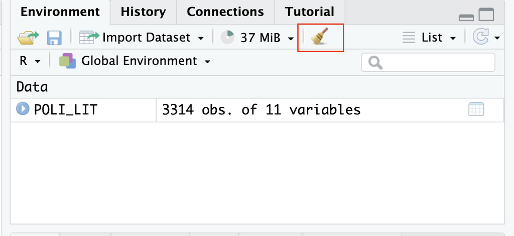

> ⚠️ The broom will **clear all your data and variables** from memory.  
> Only use it if you’re sure you want to start over — it cannot be undone.

### 3.3.2 Import and Load csv file

Now we have the package loaded, we’ll load the data we are going to visualize.

```r
## 2.  Import and Load csv  ##
# Replace the file name, let's call it "POLI_LIT" for now
POLI_LIT <-  read.csv(here("Codebook + Data/POLI_LIT_v1.csv"))

# Opens the dataset in a new tab (like an Excel sheet) so you can scroll and view the data
view(POLI_LIT)
```

### 3.3.3 Explore Your Variables

Before we make any plots, let’s check what our data looks like.

```r
## 3.  Explore Your Variables ##

# Lists all the variable (column) names in the dataset
names(POLI_LIT)

# Displays the structure of the dataset:
# - how many rows and columns
# - each variable’s type (numeric, character, factor, etc.)
# - shows a few example values for each variable
str(POLI_LIT)

# Check the exact country and year column names in your data:
summary(POLI_LIT$v2x_polyarchy)  # EDI summary
summary(POLI_LIT$year)           # year range
```

*Recap: The Console shows the result of your code, like this:*

[figure not shown]

### 3.3.4 Create Your First Plot (Step by Step)

Now let’s make our plot step by step!

In this part, we’ll walk through a complete code chunk and explain what each line does. You’ll also learn how to **customize your plot**, including how to add a title and change colors.

Follow along carefully:

- Read the code and the comments
- Try running each line to see what it changes
- By the end, you’ll have a complete plot

Once you’re done, *save the plot as a PDF or png* and upload it to Blackboard under the Optional Practice tab.

#### 3.3.4.1 Subset: India, 2004–2014

For this plot, we’ll focus on **India’s Electoral Democracy Index (EDI)** between 2004 and 2014.

To make things easier, we’ll create a **subset** of the data that only includes India during that time period. This won’t change the original dataset — it just creates a new, smaller dataset from it so we can focus on what we need.

```r
# Subset: India, 2004–2014
# Use logical conditions; arrange for a clean time series
df_india <- POLI_LIT %>%
  filter(country_name == "India" & year >= 2004 & year <= 2014)
```

- `data %>%` — the pipe operator (`%>%`) passes the dataset forward to the next function, letting us read the code in order: “Take data, then filter it…”
- `filter()` keeps only the rows that meet the conditions inside.
- `country_name == "India"` keeps rows where the country is India.
- `&` means “AND”, so both conditions must be true.
- `year >= 2004 & year <= 2014` keeps only years between 2004 and 2014 (inclusive).

The result, `df_india`, is a smaller dataset (a subset) with just India’s 11 yearly observations for that time window.

```r
df_india      # sanity check: expect 11 rows (2004–2014)
```

```
##      X year country_name country_id v2x_polyarchy e_gdppc e_regionpol_6C
## 1  665 2004        India         39         0.731   3.155              6
## 2  666 2005        India         39         0.719   3.372              6
## 3  667 2006        India         39         0.722   3.610              6
## 4  668 2007        India         39         0.722   3.834              6
## 5  669 2008        India         39         0.722   4.014              6
## 6  670 2009        India         39         0.698   4.240              6
## 7  671 2010        India         39         0.688   4.542              6
## 8  672 2011        India         39         0.688   4.773              6
## 9  673 2012        India         39         0.674   5.009              6
## 10 674 2013        India         39         0.663   5.217              6
## 11 675 2014        India         39         0.624   5.517              6
##    demregion v2smgovsmcenprc v2x_gender IGO_count IGO_participation_level
## 1  0.4171786           0.788      0.684        86                    High
## 2  0.4190714           0.788      0.684        86                    High
## 3  0.4024286           0.788      0.675        88                    High
## 4  0.3886786           0.709      0.679        88                    High
## 5  0.4240714           0.709      0.675        92                    High
## 6  0.4459643           0.709      0.682        91                    High
## 7  0.4500714           0.215      0.676        92                    High
## 8  0.4560000           0.215      0.676        92                    High
## 9  0.4523571           0.215      0.676        92                    High
## 10 0.4398929           0.198      0.665        94                    High
## 11 0.4359286          -0.388      0.659        92                    High
```

Now that we have filtered India’s data for 2004–2014, let’s create a simple **line plot** showing how India’s Electoral Democracy Index (EDI) changed over time.

In `ggplot2`, each new element (like points, labels, or colors) is added layer by layer with a `+` sign.

#### 3.3.4.2 Minimal Line Plot

Now that we have filtered India’s data for 2004–2014, let’s create a simple **line plot** showing how India’s Electoral Democracy Index (EDI) changed over time.

In `ggplot2`, each new element (like points, labels, or colors) is added layer by layer with a `+` sign.

- `ggplot(df_india, aes(...))` tells R which dataset and which variables to plot.
- `aes(x = year, y = v2x_polyarchy)` maps “year” to the horizontal axis and “EDI (variable name:`v2x_polyarchy`)” to the vertical axis.
- `geom_line()` draws a continuous line showing change over time.
- The result is a basic line chart with no customized labels or style.

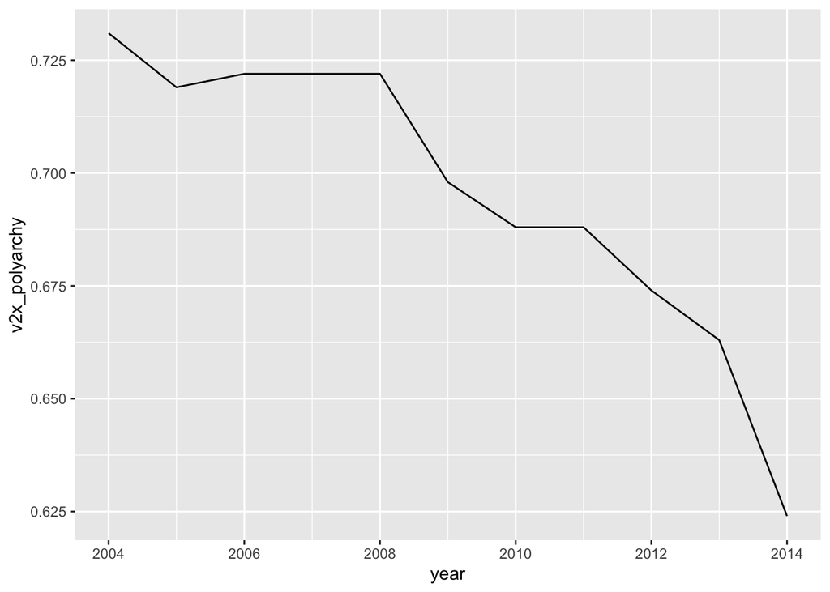

```r
p <- ggplot(df_india, aes(x = year, y = v2x_polyarchy)) +
  geom_line()

p # this will show the plot
```

In this example, we use `<-` to *assign* the plot to a name — in this case, we call it **`p`**.

That means `p` now stores the entire plot we just built using `ggplot()`. You can think of `p` like a saved object — now anytime you type `p`, it will the plot named `p`.

#### 3.3.4.3 Add Points for Readability

- The `+` adds another layer to the existing plot `p`.
- `geom_point()` places dots on each year’s EDI value, helping you see exact data points.
- The same plot `p` now contains both the line and the points.

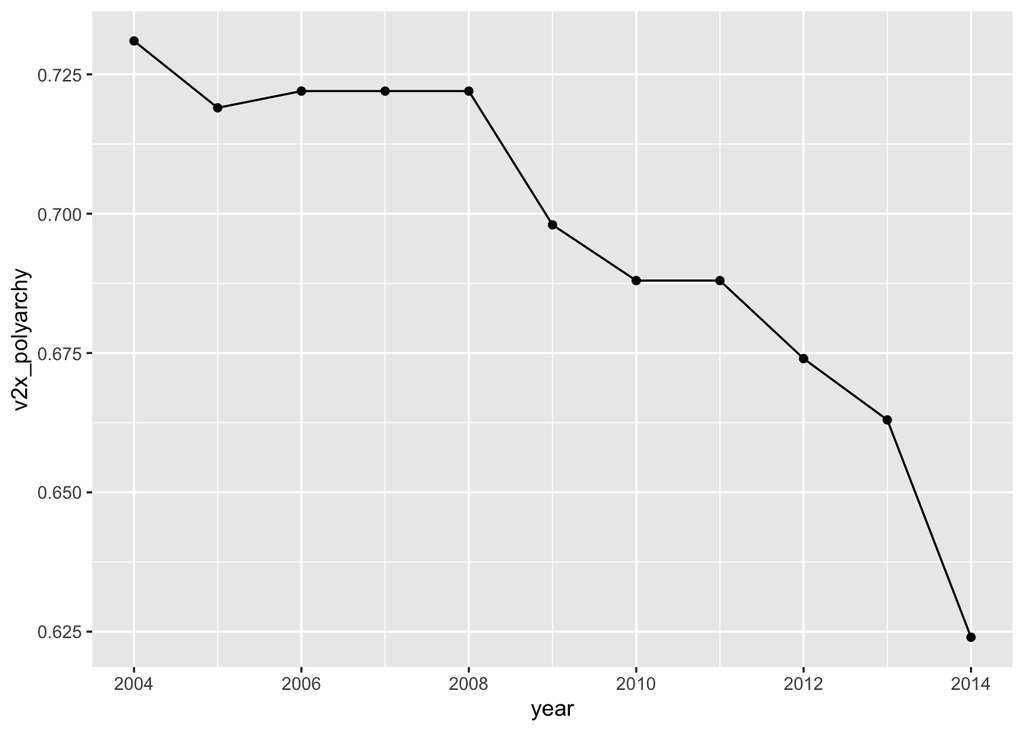

```r
p <- ggplot(df_india, aes(x = year, y = v2x_polyarchy)) +
  geom_line()+
  geom_point()
p
```

#### 3.3.4.4 Add Title, Labels, and a Clean Theme

- `labs()` adds a descriptive title and axis labels.
- The names inside quotation marks will appear on your plot.
- `theme_minimal()` changes the background and grid style to a cleaner look.

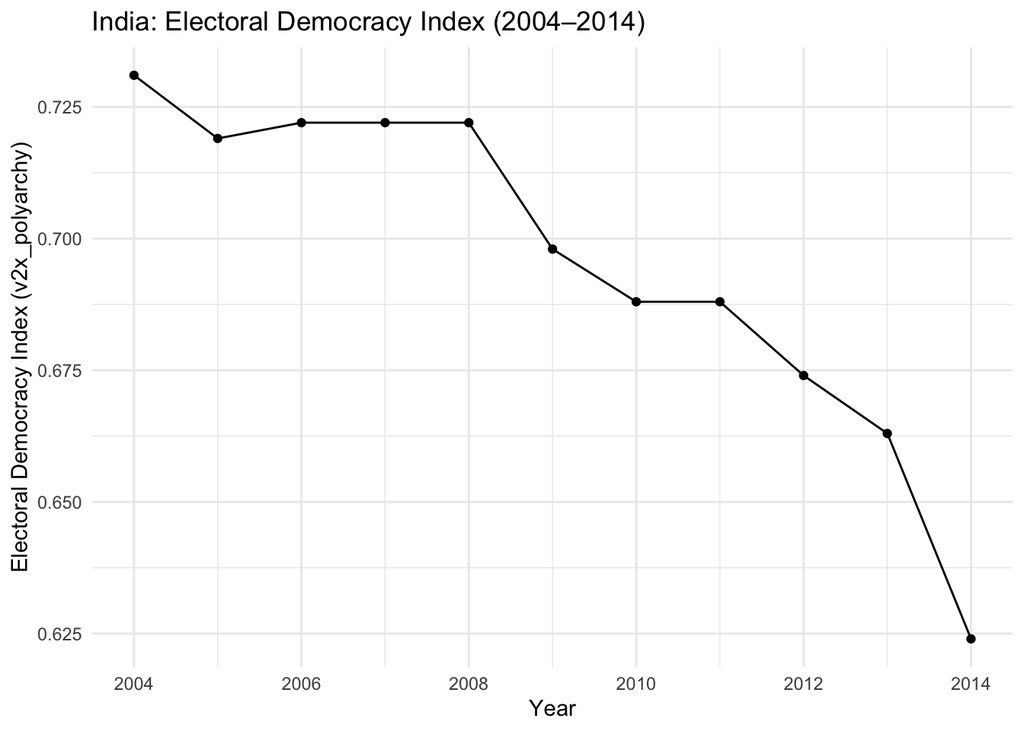

```r
p <- ggplot(df_india, aes(x = year, y = v2x_polyarchy)) +
  geom_line()+
  geom_point()+
  labs(
    title = "India: Electoral Democracy Index (2004–2014)",
    x = "Year",
    y = "Electoral Democracy Index (v2x_polyarchy)"
  ) +
  theme_minimal()
p
```

#### 3.3.4.5 Adjust the Appearance

We can change the overall look of a plot using built-in themes. `ggplot2` offers several options: `theme_minimal()`, `theme_bw()`, `theme_classic()`, etc.

- The theme controls how the background, gridlines, and text look.
- `theme_bw()` gives a clean black-and-white style often used for academic charts.

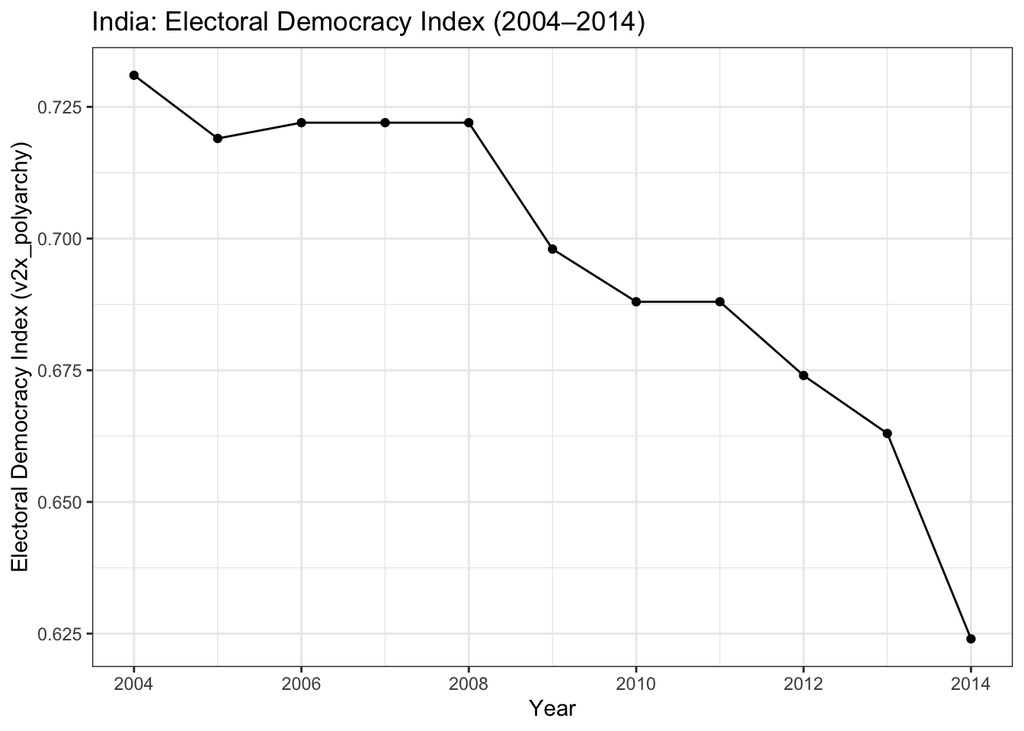

```r
p <- ggplot(df_india, aes(x = year, y = v2x_polyarchy)) +
  geom_line() +
  geom_point() +
  labs(
    title = "India: Electoral Democracy Index (2004–2014)",
    x = "Year",
    y = "Electoral Democracy Index (v2x_polyarchy)"
  ) +
  theme_bw()    # Try changing this to theme_minimal(), theme_light(), or theme_classic()
p
```

- You can experiment with other themes like:
  - `theme_minimal()`: simple and modern
  - `theme_light()`: bright with light grid lines
  - `theme_classic()`: plain background, no grid lines

> 🔍 Besides themes, in `ggplot2`, you can modify almost every elements by addin more arguments or layers. To explore more available themes, check out this guide: [ggplot2 Theme Gallery](https://ggplot2.tidyverse.org/reference/ggtheme.html)

## 3.4 Optional Pratice Plot: change the country

We’ve gone through each step together — now it’s time for you to try it on your own!

Your task:  
Pick **one country** (other than *India* or *Brazil*) and create a customized plot of the Electoral Democracy Index (EDI) from 2004 to 2014.

Your Goals:

- Choose a country
- Make a subset
- Make a plot for your country
  - Try different themes: `theme_light()`, `theme_classic()`, `theme_minimal()`, etc.
  - Edit the *title* and *labels* to match your country
- Save your plot as a *PDF or png* (or screenshot)
- 📤 Submit your plot to Blackboard

### 3.4.1 See what countries are available

Now that you’ve followed the full example, it’s your turn to try it with a **different country**!

Run the code below to see a list of all country names.  
These will print out in the **Console**, so you can choose one we haven’t used yet.

```r
# This line shows all the unique country names in the dataset 'POLI_LIT'
# $country_name tells R to look at just the 'country_name' column
# unique() returns each country name only once (no repeats)

unique(POLI_LIT$country_name)
```

```
##   [1] "Mexico"         "Suriname"       "Sweden"         "Switzerland"
##   [5] "Ghana"          "Japan"          "Russia"         "Albania"
##   [9] "Egypt"          "Yemen"          "Colombia"       "Poland"
##  [13] "Brazil"         "United States"  "Portugal"       "Bangladesh"
##  [17] "Bolivia"        "Haiti"          "Honduras"       "Pakistan"
##  [21] "Senegal"        "Sudan"          "Vietnam"        "Afghanistan"
##  [25] "Argentina"      "Ethiopia"       "India"          "Kenya"
##  [29] "Kosovo"         "Lebanon"        "Nigeria"        "Philippines"
##  [33] "Tanzania"       "Taiwan"         "Thailand"       "Uganda"
##  [37] "Venezuela"      "Benin"          "Bhutan"         "Burkina Faso"
##  [41] "Cambodia"       "Indonesia"      "Mozambique"     "Nepal"
##  [45] "Nicaragua"      "Niger"          "Zambia"         "Zimbabwe"
##  [49] "Guinea"         "Mauritania"     "Canada"         "Australia"
##  [53] "Botswana"       "Burundi"        "Chile"          "Ecuador"
##  [57] "France"         "Germany"        "Guatemala"      "Ireland"
```

[output cut: 19 more lines]

### 3.4.2 Pick a country you want to explore, make a subset

```r
# Here, we change it "Brazil" as example
# And we name the subset "df_brazil"

df_brazil <- POLI_LIT %>%
  filter(country_name == "Brazil" & year >= 2004 & year <= 2014)

df_brazil     # sanity check: expect 11 rows (2004–2014)
```

> 💡 In R, spelling and capitalization matter — the names must **match exactly**. For example, if the dataset uses `"United Kingdom"`, then `"UK"`, `"united kingdom"`, or `"United kingdom"` will not work. To avoid errors, copy the country name *directly from the Console* using `unique()`.

### 3.4.3 Rebuild the plot using the subset

```r
# Replace 'df_brazil' to your subset
# Change the country name in title

p <- ggplot(df_brazil, aes(x = year, y = v2x_polyarchy)) +
  geom_line() +
  geom_point() +
  labs(
    title = "Brazil: Electoral Democracy Index (2004-2014)",
    x = "Year",
    y = "Electoral Democracy Index (v2x_polyarchy)"
  ) +
  theme_minimal()
p
```

> ⚠️ If a country has missing years or `NA` values in its EDI score, the plot may have gaps or fewer points.  
> That’s normal — data coverage varies across countries and years.  
> If you get **0 rows**, double-check spelling and data coverage (the country exists in the data between 2004 and 2014).

### 3.4.4 Save the plot

Now that you’ve created your custom plot, it’s time to save it as a file so you can submit it.

In R, we use the `ggsave()` function to save a plot to your working folder as a **PDF, PNG, or other file format**.

```r
# Save your current plot as a PDF (best for printing or submission)
# Rename the file to match your selected country and last name

ggsave("SELECTEDCOUNTRY_LASTNAME.pdf", plot = p, width = 7, height = 5)

## ggsave("Brazil_Chen.pdf", plot = p, width = 7, height = 5)
```

> 💡 What does `ggsave()` do?  
> It takes the last plot you created (in this case, p) and saves it as a file in your working directory (Posit Cloud project folder). This lets you download it and submit it outside of RStudio — for example, uploading to Blackboard.
- If Download Doesn’t Work
- Take a screenshot of your plot from the Plots pane
- Make sure your title, axes, and years (2004–2014) are visible
- Save the screenshot as a backup for submission

**Alternative: Save Directly from R Studio**

If `ggsave()` feels confusing, you can also export your plot manually using the R Studio interface.

1. After running your plotting code, go to the Plots pane (bottom-right corner).
2. Click the “Export” button right above your plot.
3. Choose “Save as Image…” or “Save as PDF…”
4. In the pop-up window:
   - Rename your file, e.g. `Brazil_Chen.pdf`
   - Choose where to save it (the default is your Posit project folder).
5. Click Save — you’ll see your file appear in the Files pane.

### 3.4.5 Download the saved file from Posit Cloud

1. Look at the Files pane in Posit Cloud (bottom-right corner).
2. Find your saved file — it should appear there.
3. Click the checkbox next to the file name.
4. Click the “More” (⋯) menu or the gear icon, then choose Export → Download to save it to your computer.
5. Rename it with your chosen country, for example: `Taiwan_Chen.pdf`
6. Upload this file in Blackboard → Optional Practice Plot.

[figure not shown]

## 3.5 Knowledge check

### 3.5.1 Pratice Quiz

**1. You must install `ggplot2` every time you open a new R session.**

a) True

b) False

**2. The pipe operator `%>%` helps you write R code that reads step by step.**

a) True

b) False

**3. What happens if you click the broom icon in the Environment pane?**

a) Deletes files from your project

b) Clears all datasets and variables from memory

c) Clears your current plot

# 4 Unit 2 Summary

In this unit, you’ve taken your first real steps into data analysis with R. Here’s a recap of what you covered:

**Setting Up Your Environment**  
You created a Posit Cloud account, opened your first R project, and learned how the RStudio interface is organized across four panels: the Script Editor, Console, Environment, and Files/Plots pane.

**R Fundamentals**  
You practiced the core logic of R — running code line by line, using comments with `#`, storing values in named objects with `<-`, and working with different data types (`character`, `numeric`, `integer`, `logical`, `factor`). You also learned how to access columns in a dataset using the `$` operator and how to use `filter()` and the pipe `%>%` to create subsets of your data.

**Loading and Exploring Data**  
You uploaded the `POLI_LIT_v1.csv` dataset into Posit Cloud, read it into R with `read.csv()`, and used functions like `head()`, `str()`, and `summary()` to inspect its contents before plotting.

**Building Visualizations with `ggplot2`**  
Starting from a minimal line plot, you built up a complete visualization of India’s Electoral Democracy Index (2004–2014), adding `geom_point()` for readability, `labs()` for informative titles and axis labels, and `theme_*()` functions to control the overall visual style.

**Saving and Submitting Your Work**  
You used `ggsave()` to export your plot and practiced downloading files from Posit Cloud for submission.

**To receive full credit for Unit 2** (worth **5% of the course grade**):

1. Submit the **Final Practice** assignment — one plot of a country of your choice, plus a short written description.
2. Complete the **Unit 2 Feedback Survey** on Blackboard.

> 💡 *Don’t worry if some of the code still feels unfamiliar — that’s completely normal at this stage. The most important thing is that you’ve started building a foundation. Each time you run code and see what it does, that understanding grows.*